# Tugas Praktikum 3 MPDW

# Data

```r
library(dLagM)
library(dynlm)
library(MLmetrics)
library(lmtest)
library(car)

data <- read.csv("C:\\Users\\HP\\OneDrive\\Documents\\NewDelhi_Air_quality.csv")

data.model <- data[, c("AQI", "o3")]
names(data.model) <- c("Yt", "Xt")

head(data.model)
```

```
##     Yt       Xt
## 1 30.2 55.78995
## 2 28.2 54.93164
## 3 26.6 54.64554
## 4 25.0 55.07469
## 5 26.0 55.78995
## 6 26.0 56.50520
```

```r
summary(data.model)
```

```
##        Yt              Xt
##  Min.   :19.00   Min.   :41.48
##  1st Qu.:25.00   1st Qu.:53.64
##  Median :27.00   Median :57.22
##  Mean   :26.18   Mean   :56.57
##  3rd Qu.:28.00   3rd Qu.:60.08
##  Max.   :32.00   Max.   :68.66
```

```r
sum(is.na(data.model))
```

```
## [1] 0
```

Pada analisis ini, AQI digunakan sebagai peubah dependen ($Y_t$), sedangkan O$_3$ sebagai peubah independen ($X_t$). O$_3$ dipilih karena memiliki hubungan paling kuat dengan AQI dibandingkan peubah lainnya.

Data kemudian dibagi menjadi data training sebesar 80% dan data testing sebesar 20%.

```r
n <- nrow(data.model)
n.train <- floor(0.8 * n)

train <- data.model[1:n.train, ]
test <- data.model[(n.train + 1):n, ]

nrow(train)
```

```
## [1] 57
```

```r
nrow(test)
```

```
## [1] 15
```

# Model Koyck

Model Koyck memasukkan peubah bebas saat ini ($X_t$) dan lag dari peubah tak bebas ($Y_{t-1}$).

```r
model.koyck <- koyckDlm(
  x = train$Xt,
  y = train$Yt
)

summary(model.koyck)
```

```
##
## Call:
## "Y ~ (Intercept) + Y.1 + X.t"
##
## Residuals:
##       Min        1Q    Median        3Q       Max
## -1.127670 -0.301407  0.001002  0.262601  1.103471
##
## Coefficients:
##             Estimate Std. Error t value Pr(>|t|)
## (Intercept)  0.54798    0.92878   0.590    0.558
## Y.1          0.41955    0.08223   5.102 4.63e-06 ***
## X.t          0.25830    0.04107   6.289 6.25e-08 ***
## ---
## Signif. codes:  0 '***' 0.001 '**' 0.01 '*' 0.05 '.' 0.1 ' ' 1
##
## Residual standard error: 0.5053 on 53 degrees of freedom
## Multiple R-Squared: 0.9463,  Adjusted R-squared: 0.9443
## Wald test: 423.7 on 2 and 53 DF,  p-value: < 2.2e-16
##
## Diagnostic tests:
## NULL
##
##                             alpha      beta       phi
## Geometric coefficients:  0.944071 0.2582957 0.4195528
```

## Forecasting Model Koyck

```r
fore.koyck <- forecast(
  model = model.koyck,
  x = test$Xt,
  h = nrow(test)
)

mape.koyck <- MAPE(
  fore.koyck$forecasts,
  test$Yt
)

deviance.koyck <- sum(
  (test$Yt - fore.koyck$forecasts)^2
)

mape.koyck
```

```
## [1] 0.03187326
```

```r
deviance.koyck
```

```
## [1] 10.14643
```

# Distributed Lag Model (DLM)

Pada Distributed Lag Model, peubah bebas dapat memberikan pengaruh terhadap peubah tak bebas pada beberapa periode waktu. Penentuan lag optimum dilakukan menggunakan AIC.

```r
dlm.opt <- finiteDLMauto(
  formula = Yt ~ Xt,
  data = data.frame(train),
  q.min = 1,
  q.max = 10,
  model.type = "dlm",
  error.type = "AIC",
  trace = TRUE
)

dlm.opt
```

```
##    q - k    MASE      AIC      BIC     GMRAE   MBRAE R.Adj.Sq  Ljung-Box
## 10    10 0.35051 22.97129 47.02321 14499.820 0.49589  0.98302 0.35474502
## 3      3 0.39875 27.06744 39.00134  6447.089 0.49480  0.98198 0.10728965
## 5      5 0.38245 27.17252 42.78247  7468.898 0.49506  0.98252 0.17930776
## 4      4 0.39892 27.90158 41.69362  8742.382 0.49838  0.98187 0.16589034
## 9      9 0.38342 29.59952 52.05393 11575.966 0.50164  0.98105 0.83879203
## 6      6 0.38046 29.81810 47.20453  6019.920 0.48473  0.98200 0.19113496
## 7      7 0.39444 30.91101 50.03124  7435.980 0.49025  0.98199 0.27024407
## 8      8 0.40121 31.26668 52.07671 10182.702 0.51165  0.98151 0.41738843
## 2      2 0.42869 46.47280 56.50947  6714.446 0.48891  0.97365 0.08751929
## 1      1 0.50971 90.38861 98.49001  6923.684 0.40817  0.94126 0.16081431
```

```r
q.opt <- dlm.opt[which.min(dlm.opt$AIC), "q - k"]
q.opt
```

```
## [1] 10
```

```r
model.dlm.opt <- dlm(
  x = train$Xt,
  y = train$Yt,
  q = q.opt
)

summary(model.dlm.opt)
```

```
##
## Call:
## lm(formula = model.formula, data = design)
##
## Residuals:
##     Min      1Q  Median      3Q     Max
## -0.5204 -0.1663  0.0356  0.1624  0.5130
##
## Coefficients:
##              Estimate Std. Error t value Pr(>|t|)
## (Intercept) -0.294780   0.931786  -0.316  0.75361
## x.t          0.405638   0.063702   6.368 2.54e-07 ***
## x.1          0.159000   0.133129   1.194  0.24038
## x.2         -0.052741   0.126788  -0.416  0.67997
## x.3         -0.148621   0.121282  -1.225  0.22860
## x.4          0.143544   0.124404   1.154  0.25638
## x.5         -0.007047   0.123348  -0.057  0.95476
## x.6         -0.127683   0.123191  -1.036  0.30709
## x.7          0.287823   0.121937   2.360  0.02396 *
## x.8         -0.399437   0.121443  -3.289  0.00230 **
## x.9          0.304147   0.103813   2.930  0.00594 **
## x.10        -0.098958   0.048025  -2.061  0.04684 *
## ---
## Signif. codes:  0 '***' 0.001 '**' 0.01 '*' 0.05 '.' 0.1 ' ' 1
##
## Residual standard error: 0.2715 on 35 degrees of freedom
## Multiple R-squared:  0.9871, Adjusted R-squared:  0.983
## F-statistic: 243.1 on 11 and 35 DF,  p-value: < 2.2e-16
##
## AIC and BIC values for the model:
##        AIC      BIC
## 1 22.97129 47.02321
```

## Forecasting Model DLM

```r
fore.dlm.opt <- forecast(
  model = model.dlm.opt,
  x = test$Xt,
  h = nrow(test)
)

mape.dlm.opt <- MAPE(
  fore.dlm.opt$forecasts,
  test$Yt
)

deviance.dlm.opt <- sum(
  (test$Yt - fore.dlm.opt$forecasts)^2
)

mape.dlm.opt
```

```
## [1] 0.01274404
```

```r
deviance.dlm.opt
```

```
## [1] 1.700108
```

# Autoregressive Distributed Lag (ARDL)

Model ARDL memasukkan lag dari peubah bebas dan lag dari peubah tak bebas. Penentuan lag optimum dilakukan berdasarkan nilai AIC.

```r
model.ardl.opt <- ardlBoundOrders(
  data = data.frame(data.model),
  ic = "AIC",
  formula = Yt ~ Xt
)

model.ardl.opt
```

```
## $p
##   Xt
## 1 13
##
## $q
## [1] 2
##
## $Stat.table
##           q = 1    q = 2    q = 3    q = 4    q = 5    q = 6    q = 7    q = 8
## p = 1  38.64746 23.22848 25.42302 27.72031 28.70926 26.39158 27.98723 30.39158
## p = 2  22.86594 24.77455 27.31646 28.69429 28.81115 25.64963 27.33061 30.08845
## p = 3  27.18085 27.18085 28.84077 30.37243 30.71504 25.55412 27.74318 30.55048
## p = 4  27.27918 28.33392 28.33392 27.22651 29.94853 27.52594 29.31474 32.19458
## p = 5  28.22371 28.68011 29.37749 29.37749 30.12962 28.60210 31.06991 33.54724
## p = 6  27.11336 28.13965 27.00217 28.68077 28.68077 30.47844 33.06989 35.19285
## p = 7  30.19026 30.92504 29.24074 30.23773 30.81010 30.81010 29.56882 27.97012
## p = 8  26.81548 26.88306 26.96639 27.84677 26.80343 28.40155 28.40155 29.27146
## p = 9  25.15641 25.64777 25.75789 27.48094 26.12645 27.83358 29.58776 29.58776
## p = 10 28.59615 28.86775 29.29778 31.09265 28.82957 30.63888 32.57903 34.34994
## p = 11 24.53224 23.37847 24.80335 26.48648 23.35632 25.20746 26.60810 26.81938
## p = 12 27.14281 25.70395 27.06234 28.84787 26.03408 27.92602 28.91965 28.33033
## p = 13 19.25858 16.55044 18.53543 20.33824 17.61125 19.60705 21.03414 21.71506
## p = 14 20.31747 18.36045 20.36004 22.34912 19.16521 21.06710 22.41853 23.18530
## p = 15 22.41646 20.32505 22.22270 24.14701 21.64522 23.25026 24.97916 26.17790
##           q = 9   q = 10   q = 11   q = 12   q = 13   q = 14   q = 15
## p = 1  33.09252 33.18190 32.84415 33.19542 35.85663 30.71580 27.67083
## p = 2  32.80513 33.98671 32.34936 32.42167 35.04537 31.25200 27.25097
## p = 3  33.31925 34.28268 33.42041 33.94715 36.44309 32.48438 28.87461
## p = 4  34.95803 36.14844 35.27999 35.94335 38.39874 34.28870 30.56428
## p = 5  36.11311 37.41170 36.41377 37.18234 39.82841 36.17273 32.18350
## p = 6  35.88842 36.25737 35.13490 36.94569 39.67535 32.69633 29.29501
## p = 7  30.90878 33.89102 34.52801 36.37243 38.74818 31.23844 29.15791
## p = 8  31.44233 34.39275 26.01225 26.78247 27.92580 24.10080 23.75594
## p = 9  31.57509 33.98987 27.47278 26.92081 26.62574 21.91896 21.71187
## p = 10 34.34994 33.75383 24.46154 25.13892 26.98653 23.27262 23.65748
## p = 11 23.68447 23.68447 24.90968 27.13805 28.98636 25.18996 25.61717
## p = 12 25.59091 27.59091 27.59091 29.08999 29.84364 23.51211 22.55179
## p = 13 19.56880 19.27526 21.04212 21.04212 22.98266 23.87236 23.91841
## p = 14 22.81463 22.84285 24.84274 22.27955 22.27955 24.27951 25.89778
## p = 15 25.36264 24.86236 26.81668 26.73848 27.78117 27.78117 27.75060
##
## $min.Stat
## [1] 16.55044
```

```r
min_p <- c()

for(i in 1:6){
  min_p[i] <- min(model.ardl.opt$Stat.table[[i]])
}

q_opt <- which(
  min_p == min(min_p, na.rm = TRUE)
)[1]

p_opt <- which(
  model.ardl.opt$Stat.table[[q_opt]] ==
    min(model.ardl.opt$Stat.table[[q_opt]], na.rm = TRUE)
)[1]

data.frame(
  "Lag_Y_opt(q)" = q_opt,
  "Lag_X_opt(p)" = p_opt,
  "AIC" = model.ardl.opt$min.Stat
)
```

```
##   Lag_Y_opt.q. Lag_X_opt.p.      AIC
## 1            2           13 16.55044
```

```r
model.ardl <- ardlDlm(
  formula = Yt ~ Xt,
  data = train,
  p = p_opt,
  q = q_opt
)

summary(model.ardl)
```

```
##
## Time series regression with "ts" data:
## Start = 14, End = 57
##
## Call:
## dynlm(formula = as.formula(model.text), data = data)
##
## Residuals:
##      Min       1Q   Median       3Q      Max
## -0.45939 -0.19244  0.04237  0.18424  0.45823
##
## Coefficients:
##             Estimate Std. Error t value Pr(>|t|)
## (Intercept) -0.77136    1.12356  -0.687   0.4982
## Xt.t         0.39407    0.07142   5.517 7.61e-06 ***
## Xt.1         0.20786    0.18280   1.137   0.2655
## Xt.2        -0.02966    0.21795  -0.136   0.8928
## Xt.3        -0.13619    0.16006  -0.851   0.4023
## Xt.4         0.05226    0.16212   0.322   0.7497
## Xt.5         0.04957    0.14512   0.342   0.7353
## Xt.6        -0.13909    0.13618  -1.021   0.3162
## Xt.7         0.27019    0.13651   1.979   0.0581 .
## Xt.8        -0.31492    0.14669  -2.147   0.0409 *
## Xt.9         0.15294    0.16112   0.949   0.3509
## Xt.10        0.09506    0.16928   0.562   0.5790
## Xt.11       -0.16098    0.15567  -1.034   0.3103
## Xt.12        0.04585    0.12175   0.377   0.7094
## Xt.13        0.01492    0.05471   0.273   0.7871
## Yt.1        -0.12772    0.19313  -0.661   0.5140
## Yt.2         0.06633    0.21010   0.316   0.7546
## ---
## Signif. codes:  0 '***' 0.001 '**' 0.01 '*' 0.05 '.' 0.1 ' ' 1
##
## Residual standard error: 0.2868 on 27 degrees of freedom
## Multiple R-squared:  0.9884, Adjusted R-squared:  0.9814
## F-statistic: 143.2 on 16 and 27 DF,  p-value: < 2.2e-16
```

## Forecasting Model ARDL

```r
fore.ardl <- forecast(
  model = model.ardl,
  x = test$Xt,
  h = nrow(test)
)

mape.ardl <- MAPE(
  fore.ardl$forecasts,
  test$Yt
)

deviance.ardl <- sum(
  (test$Yt - fore.ardl$forecasts)^2
)

mape.ardl
```

```
## [1] 0.01378089
```

```r
deviance.ardl
```

```
## [1] 1.944001
```

# Pengujian Asumsi

## Model Koyck

```r
koyck.lm <- dynlm(
  Yt ~ Xt + L(Yt),
  data = train
)

dwtest(koyck.lm)
```

```
##
##  Durbin-Watson test
##
## data:  koyck.lm
## DW = 2.2528, p-value = 0.7658
## alternative hypothesis: true autocorrelation is greater than 0
```

```r
bptest(koyck.lm)
```

```
##
##  studentized Breusch-Pagan test
##
## data:  koyck.lm
## BP = 4.4912, df = 2, p-value = 0.1059
```

```r
shapiro.test(residuals(koyck.lm))
```

```
##
##  Shapiro-Wilk normality test
##
## data:  residuals(koyck.lm)
## W = 0.32725, p-value = 1.03e-14
```

## Model DLM

```r
train.ts <- ts(train)

dlm.lm <- dynlm(
  Yt ~ Xt + L(Xt, 1) + L(Xt, 2) + L(Xt, 3) +
       L(Xt, 4) + L(Xt, 5) + L(Xt, 6) +
       L(Xt, 7) + L(Xt, 8) + L(Xt, 9) +
       L(Xt, 10),
  data = train.ts
)

dwtest(dlm.lm)
```

```
##
##  Durbin-Watson test
##
## data:  dlm.lm
## DW = 2.2518, p-value = 0.6603
## alternative hypothesis: true autocorrelation is greater than 0
```

```r
bptest(dlm.lm)
```

```
##
##  studentized Breusch-Pagan test
##
## data:  dlm.lm
## BP = 8.9642, df = 11, p-value = 0.6252
```

```r
shapiro.test(residuals(dlm.lm))
```

```
##
##  Shapiro-Wilk normality test
##
## data:  residuals(dlm.lm)
## W = 0.97309, p-value = 0.3455
```

## Model ARDL

```r
train.ts <- ts(train)

ardl.lm <- dynlm(
  Yt ~ Xt +
    L(Xt, 1) + L(Xt, 2) + L(Xt, 3) +
    L(Xt, 4) + L(Xt, 5) + L(Xt, 6) +
    L(Xt, 7) + L(Xt, 8) + L(Xt, 9) +
    L(Xt, 10) + L(Xt, 11) + L(Xt, 12) +
    L(Xt, 13) +
    L(Yt, 1) + L(Yt, 2),
  data = train.ts
)

dwtest(ardl.lm)
```

```
##
##  Durbin-Watson test
##
## data:  ardl.lm
## DW = 1.975, p-value = 0.29
## alternative hypothesis: true autocorrelation is greater than 0
```

```r
bptest(ardl.lm)
```

```
##
##  studentized Breusch-Pagan test
##
## data:  ardl.lm
## BP = 19.115, df = 16, p-value = 0.2628
```

```r
shapiro.test(residuals(ardl.lm))
```

```
##
##  Shapiro-Wilk normality test
##
## data:  residuals(ardl.lm)
## W = 0.95989, p-value = 0.1289
```

# Perbandingan Model

Nilai MAPE dan deviance dari ketiga model dibandingkan untuk menentukan model dengan kemampuan forecasting terbaik.

```r
hasil <- data.frame(
  Model = c("Koyck", "DLM", "ARDL"),
  MAPE = c(
    mape.koyck,
    mape.dlm.opt,
    mape.ardl
  ),
  Deviance = c(
    deviance.koyck,
    deviance.dlm.opt,
    deviance.ardl
  )
)

hasil
```

```
##   Model       MAPE  Deviance
## 1 Koyck 0.03187326 10.146433
## 2   DLM 0.01274404  1.700108
## 3  ARDL 0.01378089  1.944001
```

Model dengan nilai MAPE dan deviance yang lebih kecil menunjukkan hasil forecasting yang lebih baik.

# Visualisasi Forecasting

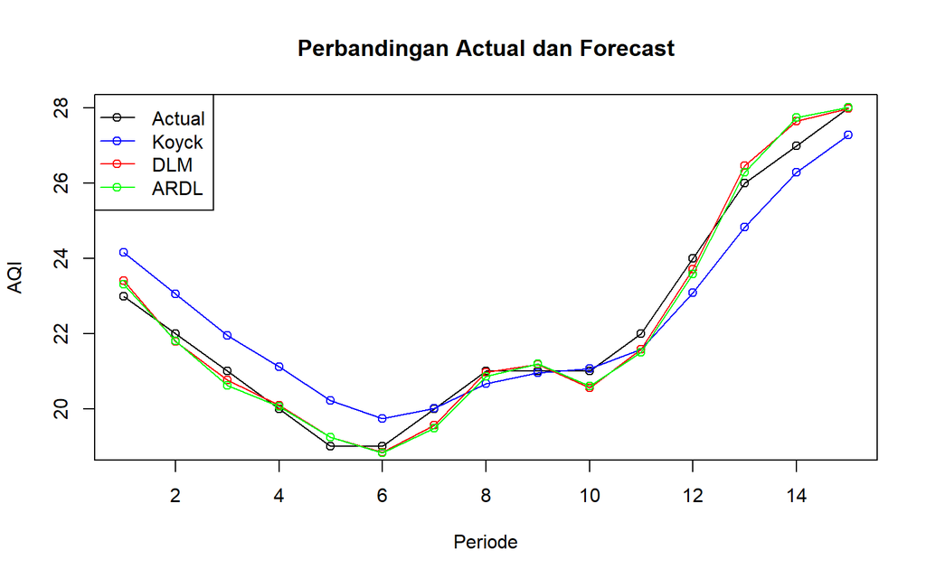

```r
plot(
  test$Yt,
  type = "o",
  col = "black",
  xlab = "Periode",
  ylab = "AQI",
  main = "Perbandingan Actual dan Forecast"
)

lines(
  fore.koyck$forecasts,
  type = "o",
  col = "blue"
)

lines(
  fore.dlm.opt$forecasts,
  type = "o",
  col = "red"
)

lines(
  fore.ardl$forecasts,
  type = "o",
  col = "green"
)

legend(
  "topleft",
  legend = c(
    "Actual",
    "Koyck",
    "DLM",
    "ARDL"
  ),
  col = c(
    "black",
    "blue",
    "red",
    "green"
  ),
  lty = 1,
  pch = 1
)
```

# Kesimpulan

Berdasarkan hasil forecasting, ketiga model yaitu Koyck, Distributed Lag Model (DLM), dan Autoregressive Distributed Lag (ARDL) dibandingkan menggunakan nilai MAPE dan deviance. Model dengan nilai MAPE dan deviance paling kecil dipilih sebagai model dengan kemampuan forecasting terbaik, yaitu DLM. Hasil pengujian asumsi juga digunakan sebagai pertimbangan dalam mengevaluasi kelayakan model.